# Exercise 5.1.5 - PCA and Clustering

W. Mangrobang

August 27, 2018

### Mortality Data

#### PCA

We’ll perform PCA on the following four numeric variables: **issage**, **attage**, **duration**, **exposure_face**

```
## Importance of components:
##                           PC1    PC2    PC3       PC4
## Standard deviation     1.3474 1.1171 0.9679 1.465e-13
## Proportion of Variance 0.4538 0.3120 0.2342 0.000e+00
## Cumulative Proportion  0.4538 0.7658 1.0000 1.000e+00
```

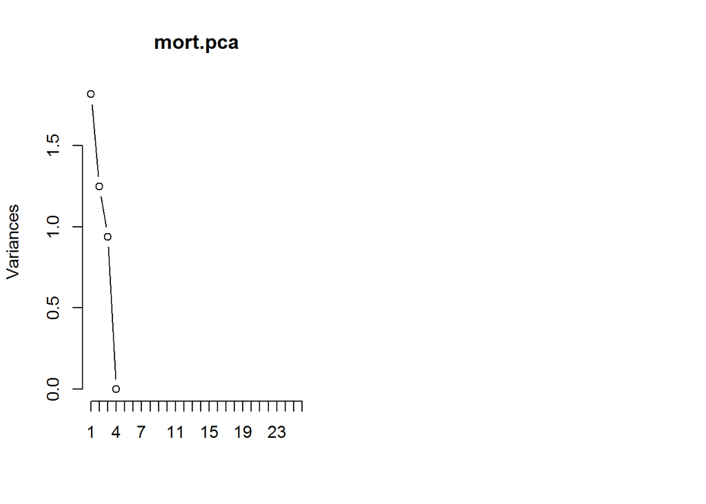

100% of the variance is explained by the first three components. It kind of makes sense because **attage** is just a linear combination of **issage** and **duration**.

Let’s look at the loadings.

```
##                      PC1         PC2         PC3           PC4
## issage         0.6277823 -0.45739183  0.15830566 -6.096076e-01
## attage        -0.1686630 -0.86918081 -0.07748501  4.583378e-01
## duration      -0.7112405 -0.18484135 -0.20412148 -6.467651e-01
## exposure_face  0.2675427  0.03392794 -0.96294850  8.326673e-17
```

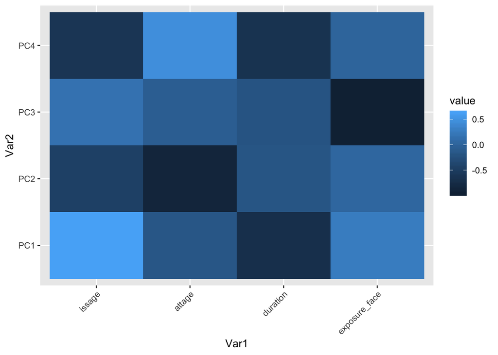

#### Clustering

For this we’ll look at attained age vs. exposure face amount.

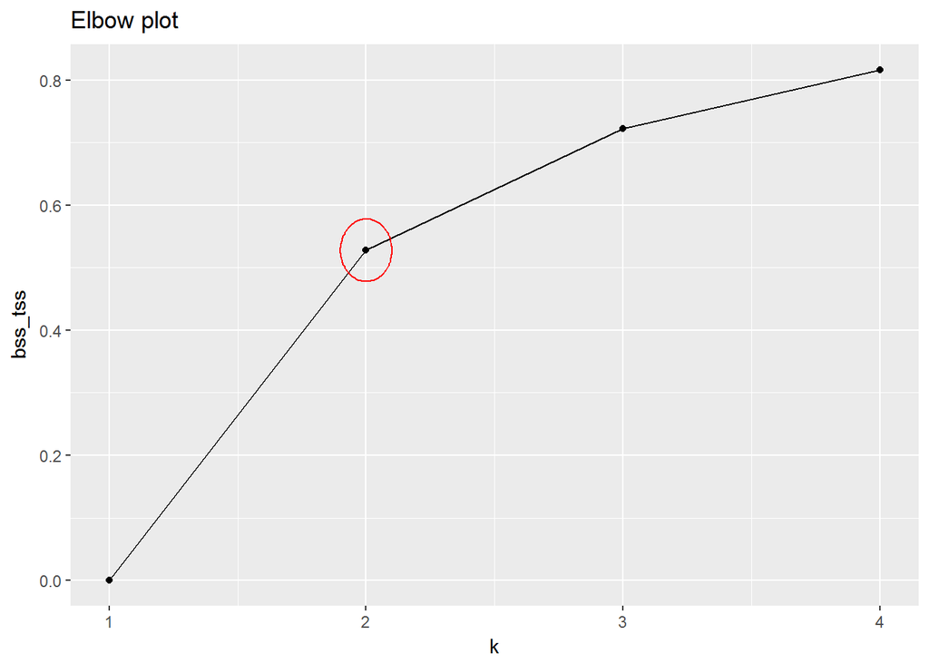

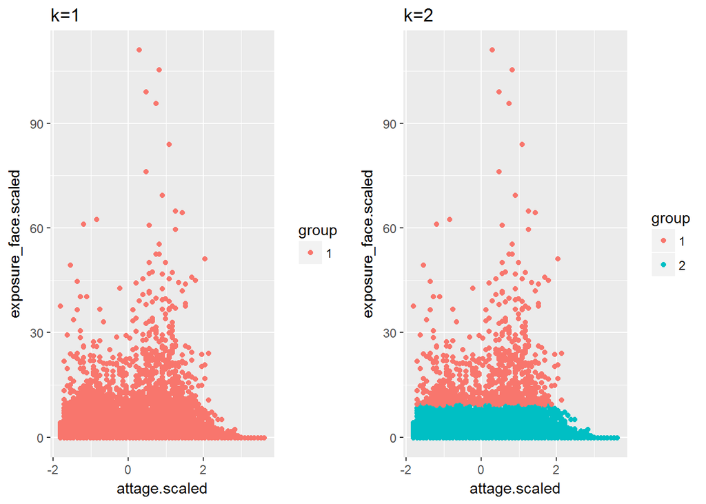

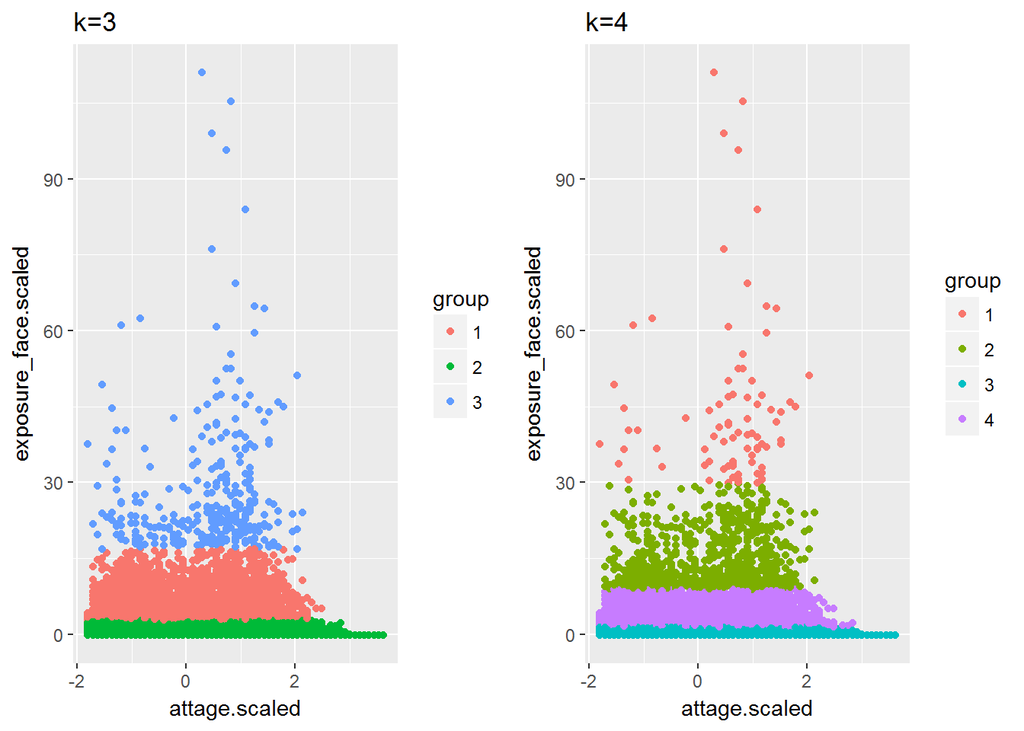

Not very intrepretable, yet. Could speculate that perhaps it would indicate something like income levels, i.e. what explains decreasing level of exposure faces as we go up the chart?

### MEPS Data

#### PCA

We’ll perform PCA on the following four numeric variables:  
**AGE14X** - AGE AS OF 12/31/14 (EDITED/IMPUTED)  
**TOTEXP14** - TOTAL HEALTH CARE EXP 14  
**WAGEP14X** - PERSON’S WAGE INCOME  
**FAMS1231** - FAMILY SIZE OF RESPONDING 12/31 FAMILY

```
##   AGE14X TOTEXP14 WAGEP14X FAMS1231
## 1     36     1518    12000        4
## 2     36     1234    56000        4
## 3     15      671        0        4
## 4      8      252        0        4
## 5     85    10904        0        1
## 6     34        0    12000        7
```

```
## 'data.frame':    34875 obs. of  4 variables:
##  $ AGE14X  : num  36 36 15 8 85 34 32 15 11 9 ...
##  $ TOTEXP14: num  1518 1234 671 252 10904 ...
##  $ WAGEP14X: num  12000 56000 0 0 0 12000 0 0 0 0 ...
##  $ FAMS1231: num  4 4 4 4 1 7 7 7 7 7 ...
```

```
## Importance of components:
##                           PC1    PC2    PC3    PC4
## Standard deviation     1.2638 1.0085 0.8988 0.7601
## Proportion of Variance 0.3993 0.2543 0.2020 0.1444
## Cumulative Proportion  0.3993 0.6536 0.8556 1.0000
```

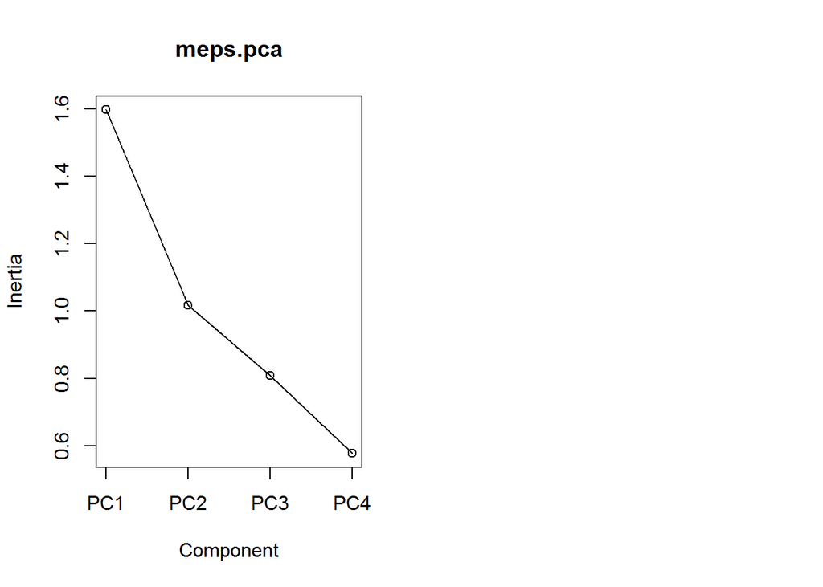

I’ve seen a few rule of thumbs for PCAs.

- Keep cumulative PCAs up to 80% of variance being explained. Here, this would be the first 3.
- Elbow rule - similar to the one discussed in the materials for clustering, this one says keep PCAs *below* the elbow. Here this would be only PCA1.

Personally, I gravitate towards the first rule.

Let’s look at the loadings.

```
##                 PC1         PC2        PC3        PC4
## AGE14X   -0.6419825  0.03585475 -0.0816531  0.7615154
## TOTEXP14 -0.3483699 -0.70951943  0.5796247 -0.1981307
## WAGEP14X -0.3704330  0.70104369  0.5371661 -0.2876974
## FAMS1231  0.5738260  0.06192229  0.6073060  0.5459568
```

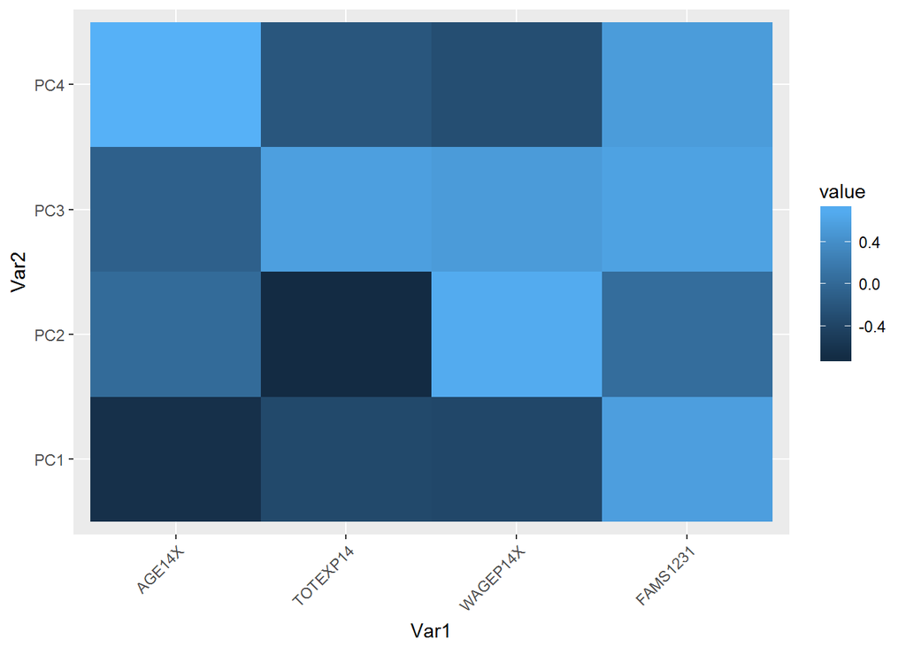

- PC1 might be an indication that if a child is in the survey, then they are likely attached to a family; vice versa, a family of one
- is likely an adult.
- PC2 might show how that higher wage earners tend to have lower expenditures; a commentary on how higher income lets you afford services that increase your standard of healthy living.
- PC3 might show how families will just have higher expenditures and wages.
- PC4 might show how older adults likely have multiple children.

#### Clustering

For this we’ll look at age and family size.

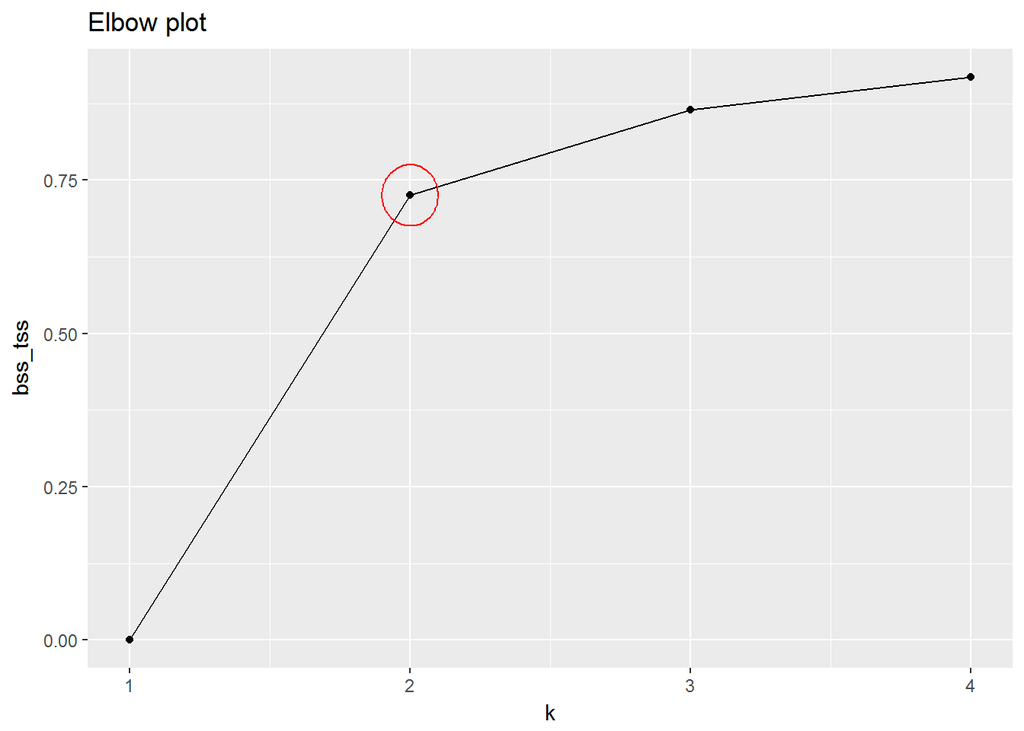

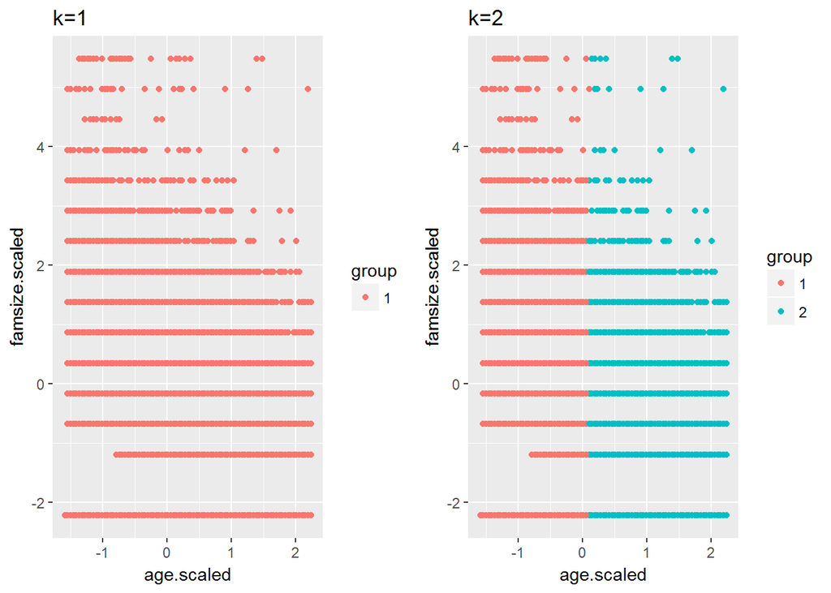

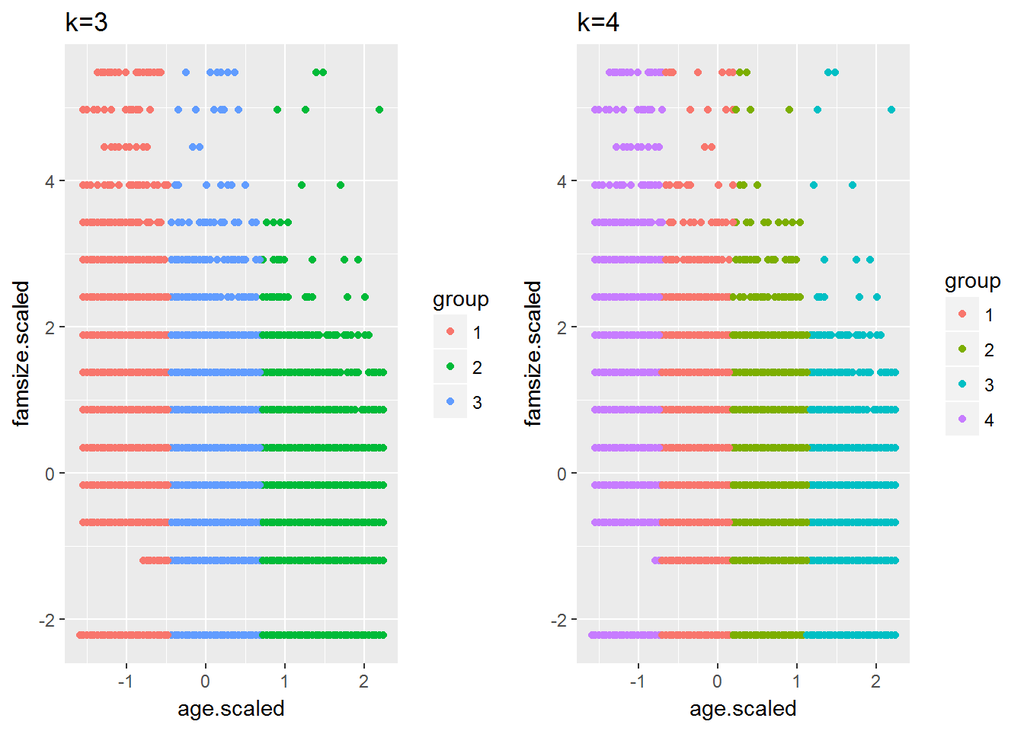

Interesting. I would say that the elbow is at 2 clusters. But I’m struggling for a straighforward interpretation. I think what the algorithm is seeing is that the that there’s more differentiation at the top end of family-sizes, which roughly coincides with the center point of age distribution. But it’s difficult to interpret, besides calling them ‘young’ vs ‘old’.